# Risk Factor Analysis

## Outcome Variable

**Outcome Variable:** ever_co

## Predictor Variables

**Intervention Variable:** hhwealth_quart

**Adjustment Set:**

- arm
- sex
- W_mage
- meducyrs
- feducyrs
- W_gagebrth
- W_birthwt
- W_birthlen
- W_nchldlt5
- W_parity
- delta_W_mage
- delta_meducyrs
- delta_feducyrs
- delta_W_gagebrth
- delta_W_birthwt
- delta_W_birthlen
- delta_W_nchldlt5
- delta_W_parity

## Stratifying Variables

The analysis was stratified on these variable(s):

- agecat
- studyid
- country

## Data Summary

| agecat | studyid | country | hhwealth_quart | ever_co | n_cell | n |
| --- | --- | --- | --- | --- | --- | --- |
| 0-24 months | ki0047075b-MAL-ED | BANGLADESH | Wealth Q4 | 0 | 19 | 82 |
| 0-24 months | ki0047075b-MAL-ED | BANGLADESH | Wealth Q4 | 1 | 2 | 82 |
| 0-24 months | ki0047075b-MAL-ED | BANGLADESH | Wealth Q1 | 0 | 14 | 82 |
| 0-24 months | ki0047075b-MAL-ED | BANGLADESH | Wealth Q1 | 1 | 7 | 82 |
| 0-24 months | ki0047075b-MAL-ED | BANGLADESH | Wealth Q2 | 0 | 14 | 82 |
| 0-24 months | ki0047075b-MAL-ED | BANGLADESH | Wealth Q2 | 1 | 6 | 82 |
| 0-24 months | ki0047075b-MAL-ED | BANGLADESH | Wealth Q3 | 0 | 17 | 82 |
| 0-24 months | ki0047075b-MAL-ED | BANGLADESH | Wealth Q3 | 1 | 3 | 82 |
| 0-24 months | ki0047075b-MAL-ED | INDIA | Wealth Q4 | 0 | 10 | 71 |
| 0-24 months | ki0047075b-MAL-ED | INDIA | Wealth Q4 | 1 | 8 | 71 |
| 0-24 months | ki0047075b-MAL-ED | INDIA | Wealth Q1 | 0 | 13 | 71 |
| 0-24 months | ki0047075b-MAL-ED | INDIA | Wealth Q1 | 1 | 6 | 71 |
| 0-24 months | ki0047075b-MAL-ED | INDIA | Wealth Q2 | 0 | 16 | 71 |
| 0-24 months | ki0047075b-MAL-ED | INDIA | Wealth Q2 | 1 | 1 | 71 |
| 0-24 months | ki0047075b-MAL-ED | INDIA | Wealth Q3 | 0 | 11 | 71 |
| 0-24 months | ki0047075b-MAL-ED | INDIA | Wealth Q3 | 1 | 6 | 71 |
| 0-24 months | ki0047075b-MAL-ED | NEPAL | Wealth Q4 | 0 | 10 | 42 |
| 0-24 months | ki0047075b-MAL-ED | NEPAL | Wealth Q4 | 1 | 1 | 42 |
| 0-24 months | ki0047075b-MAL-ED | NEPAL | Wealth Q1 | 0 | 9 | 42 |
| 0-24 months | ki0047075b-MAL-ED | NEPAL | Wealth Q1 | 1 | 2 | 42 |
| 0-24 months | ki0047075b-MAL-ED | NEPAL | Wealth Q2 | 0 | 9 | 42 |
| 0-24 months | ki0047075b-MAL-ED | NEPAL | Wealth Q2 | 1 | 1 | 42 |
| 0-24 months | ki0047075b-MAL-ED | NEPAL | Wealth Q3 | 0 | 9 | 42 |
| 0-24 months | ki0047075b-MAL-ED | NEPAL | Wealth Q3 | 1 | 1 | 42 |
| 0-24 months | ki0047075b-MAL-ED | PERU | Wealth Q4 | 0 | 8 | 37 |
| 0-24 months | ki0047075b-MAL-ED | PERU | Wealth Q4 | 1 | 2 | 37 |
| 0-24 months | ki0047075b-MAL-ED | PERU | Wealth Q1 | 0 | 9 | 37 |
| 0-24 months | ki0047075b-MAL-ED | PERU | Wealth Q1 | 1 | 0 | 37 |
| 0-24 months | ki0047075b-MAL-ED | PERU | Wealth Q2 | 0 | 7 | 37 |
| 0-24 months | ki0047075b-MAL-ED | PERU | Wealth Q2 | 1 | 2 | 37 |

[output cut: 378 more lines]

The following strata were considered:

- agecat: 0-24 months, studyid: ki0047075b-MAL-ED, country: BANGLADESH
- agecat: 0-24 months, studyid: ki0047075b-MAL-ED, country: INDIA
- agecat: 0-24 months, studyid: ki0047075b-MAL-ED, country: NEPAL
- agecat: 0-24 months, studyid: ki0047075b-MAL-ED, country: PERU
- agecat: 0-24 months, studyid: ki0047075b-MAL-ED, country: SOUTH AFRICA
- agecat: 0-24 months, studyid: ki0047075b-MAL-ED, country: TANZANIA, UNITED REPUBLIC OF
- agecat: 0-24 months, studyid: ki1000108-CMC-V-BCS-2002, country: INDIA
- agecat: 0-24 months, studyid: ki1000108-IRC, country: INDIA
- agecat: 0-24 months, studyid: ki1017093b-PROVIDE, country: BANGLADESH
- agecat: 0-24 months, studyid: ki1066203-TanzaniaChild2, country: TANZANIA, UNITED REPUBLIC OF
- agecat: 0-24 months, studyid: ki1113344-GMS-Nepal, country: NEPAL
- agecat: 0-24 months, studyid: ki1114097-CONTENT, country: PERU
- agecat: 0-24 months, studyid: ki1135781-COHORTS, country: GUATEMALA
- agecat: 0-24 months, studyid: ki1135781-COHORTS, country: PHILIPPINES
- agecat: 0-24 months, studyid: ki1148112-LCNI-5, country: MALAWI
- agecat: 0-24 months, studyid: kiGH5241-JiVitA-3, country: BANGLADESH
- agecat: 0-24 months, studyid: kiGH5241-JiVitA-4, country: BANGLADESH
- agecat: 0-6 months, studyid: ki0047075b-MAL-ED, country: BANGLADESH
- agecat: 0-6 months, studyid: ki0047075b-MAL-ED, country: INDIA
- agecat: 0-6 months, studyid: ki0047075b-MAL-ED, country: NEPAL
- agecat: 0-6 months, studyid: ki0047075b-MAL-ED, country: PERU
- agecat: 0-6 months, studyid: ki0047075b-MAL-ED, country: SOUTH AFRICA
- agecat: 0-6 months, studyid: ki0047075b-MAL-ED, country: TANZANIA, UNITED REPUBLIC OF
- agecat: 0-6 months, studyid: ki1000108-CMC-V-BCS-2002, country: INDIA
- agecat: 0-6 months, studyid: ki1000108-IRC, country: INDIA
- agecat: 0-6 months, studyid: ki1017093b-PROVIDE, country: BANGLADESH
- agecat: 0-6 months, studyid: ki1066203-TanzaniaChild2, country: TANZANIA, UNITED REPUBLIC OF
- agecat: 0-6 months, studyid: ki1113344-GMS-Nepal, country: NEPAL
- agecat: 0-6 months, studyid: ki1114097-CONTENT, country: PERU
- agecat: 0-6 months, studyid: ki1135781-COHORTS, country: GUATEMALA
- agecat: 0-6 months, studyid: ki1135781-COHORTS, country: PHILIPPINES
- agecat: 0-6 months, studyid: ki1148112-LCNI-5, country: MALAWI
- agecat: 0-6 months, studyid: kiGH5241-JiVitA-3, country: BANGLADESH
- agecat: 0-6 months, studyid: kiGH5241-JiVitA-4, country: BANGLADESH
- agecat: 6-24 months, studyid: ki0047075b-MAL-ED, country: BANGLADESH
- agecat: 6-24 months, studyid: ki0047075b-MAL-ED, country: INDIA
- agecat: 6-24 months, studyid: ki0047075b-MAL-ED, country: NEPAL
- agecat: 6-24 months, studyid: ki0047075b-MAL-ED, country: PERU
- agecat: 6-24 months, studyid: ki0047075b-MAL-ED, country: SOUTH AFRICA
- agecat: 6-24 months, studyid: ki0047075b-MAL-ED, country: TANZANIA, UNITED REPUBLIC OF
- agecat: 6-24 months, studyid: ki1000108-CMC-V-BCS-2002, country: INDIA
- agecat: 6-24 months, studyid: ki1000108-IRC, country: INDIA
- agecat: 6-24 months, studyid: ki1017093b-PROVIDE, country: BANGLADESH
- agecat: 6-24 months, studyid: ki1066203-TanzaniaChild2, country: TANZANIA, UNITED REPUBLIC OF
- agecat: 6-24 months, studyid: ki1113344-GMS-Nepal, country: NEPAL
- agecat: 6-24 months, studyid: ki1114097-CONTENT, country: PERU
- agecat: 6-24 months, studyid: ki1135781-COHORTS, country: GUATEMALA
- agecat: 6-24 months, studyid: ki1135781-COHORTS, country: PHILIPPINES
- agecat: 6-24 months, studyid: ki1148112-LCNI-5, country: MALAWI
- agecat: 6-24 months, studyid: kiGH5241-JiVitA-3, country: BANGLADESH
- agecat: 6-24 months, studyid: kiGH5241-JiVitA-4, country: BANGLADESH

### Dropped Strata

Some strata were dropped due to rare outcomes:

- agecat: 0-24 months, studyid: ki0047075b-MAL-ED, country: BANGLADESH
- agecat: 0-24 months, studyid: ki0047075b-MAL-ED, country: INDIA
- agecat: 0-24 months, studyid: ki0047075b-MAL-ED, country: NEPAL
- agecat: 0-24 months, studyid: ki0047075b-MAL-ED, country: PERU
- agecat: 0-24 months, studyid: ki0047075b-MAL-ED, country: SOUTH AFRICA
- agecat: 0-24 months, studyid: ki0047075b-MAL-ED, country: TANZANIA, UNITED REPUBLIC OF
- agecat: 0-24 months, studyid: ki1114097-CONTENT, country: PERU
- agecat: 0-6 months, studyid: ki0047075b-MAL-ED, country: BANGLADESH
- agecat: 0-6 months, studyid: ki0047075b-MAL-ED, country: INDIA
- agecat: 0-6 months, studyid: ki0047075b-MAL-ED, country: NEPAL
- agecat: 0-6 months, studyid: ki0047075b-MAL-ED, country: PERU
- agecat: 0-6 months, studyid: ki0047075b-MAL-ED, country: SOUTH AFRICA
- agecat: 0-6 months, studyid: ki0047075b-MAL-ED, country: TANZANIA, UNITED REPUBLIC OF
- agecat: 0-6 months, studyid: ki1000108-CMC-V-BCS-2002, country: INDIA
- agecat: 0-6 months, studyid: ki1017093b-PROVIDE, country: BANGLADESH
- agecat: 0-6 months, studyid: ki1066203-TanzaniaChild2, country: TANZANIA, UNITED REPUBLIC OF
- agecat: 0-6 months, studyid: ki1114097-CONTENT, country: PERU
- agecat: 0-6 months, studyid: ki1135781-COHORTS, country: GUATEMALA
- agecat: 0-6 months, studyid: ki1148112-LCNI-5, country: MALAWI
- agecat: 6-24 months, studyid: ki0047075b-MAL-ED, country: BANGLADESH
- agecat: 6-24 months, studyid: ki0047075b-MAL-ED, country: INDIA
- agecat: 6-24 months, studyid: ki0047075b-MAL-ED, country: NEPAL
- agecat: 6-24 months, studyid: ki0047075b-MAL-ED, country: PERU
- agecat: 6-24 months, studyid: ki0047075b-MAL-ED, country: SOUTH AFRICA
- agecat: 6-24 months, studyid: ki0047075b-MAL-ED, country: TANZANIA, UNITED REPUBLIC OF
- agecat: 6-24 months, studyid: ki1114097-CONTENT, country: PERU

## Methods Detail

We’re interested in the causal parameters $E[Y_a]$ for all values of $a \in \mathcal{A}$. These parameters represent the mean outcome if, possibly contrary to fact, we intervened to set all units to have $A=a$. Under the randomization and positivity assumptions, these are identified by the statistical parameters $\psi_a=E_W[E_{Y|A,W}(Y|A=a,W)]$. In addition, we’re interested in the mean of $Y$, $E[Y]$ under no intervention (the observed mean). We will estimate these parameters by using SuperLearner to fit the relevant likelihood factors – $E_{Y|A,W}(Y|A=a,W)$ and $p(A=a|W)$, and then updating our likelihood fit using a joint TMLE.

For unadjusted analyses ($W=\{\}$), initial likelihoods were estimated using Lrnr_glm to estimate the simple $E(Y|A)$ and Lrnr_mean to estimate $p(A)$. For adjusted analyses, a small library containing Lrnr_glmnet, Lrnr_xgboost, and Lrnr_mean was used.

Having estimated these parameters, we will then use the delta method to estimate relative risks and attributable risks relative to a prespecified baseline level of $A$.

# Results Detail

## Results Plots

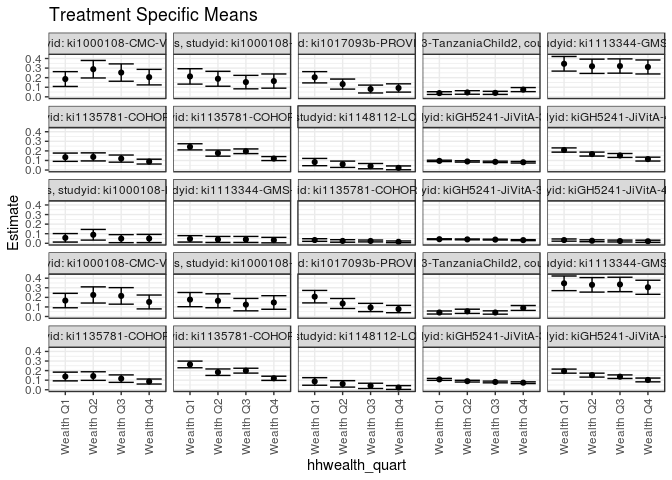

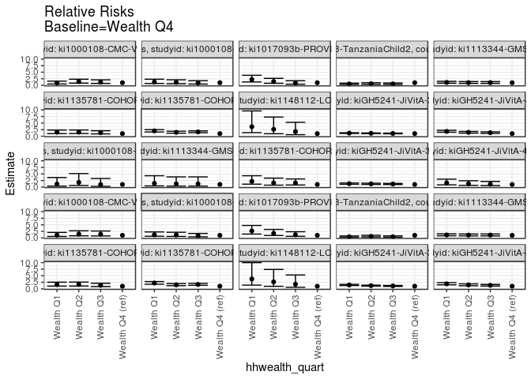

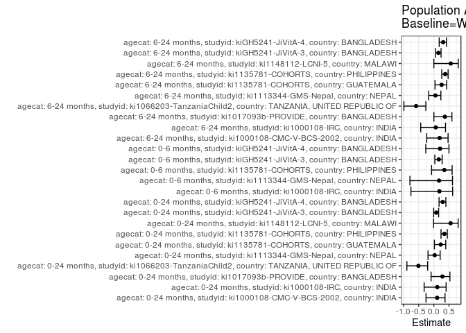

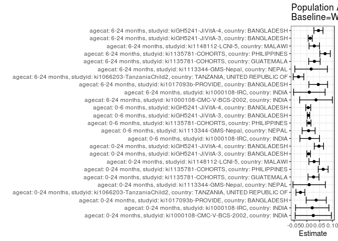

## Results Table

### Parameter: TSM

| agecat | studyid | country | intervention_level | baseline_level | estimate | ci_lower | ci_upper |
| --- | --- | --- | --- | --- | --- | --- | --- |
| 0-24 months | ki1000108-CMC-V-BCS-2002 | INDIA | Wealth Q4 | NA | 0.2055005 | 0.1242718 | 0.2867293 |
| 0-24 months | ki1000108-CMC-V-BCS-2002 | INDIA | Wealth Q1 | NA | 0.1855326 | 0.1081860 | 0.2628792 |
| 0-24 months | ki1000108-CMC-V-BCS-2002 | INDIA | Wealth Q2 | NA | 0.2882172 | 0.1969372 | 0.3794973 |
| 0-24 months | ki1000108-CMC-V-BCS-2002 | INDIA | Wealth Q3 | NA | 0.2532313 | 0.1628605 | 0.3436021 |
| 0-24 months | ki1000108-IRC | INDIA | Wealth Q4 | NA | 0.1644058 | 0.0901180 | 0.2386936 |
| 0-24 months | ki1000108-IRC | INDIA | Wealth Q1 | NA | 0.2131194 | 0.1329752 | 0.2932636 |
| 0-24 months | ki1000108-IRC | INDIA | Wealth Q2 | NA | 0.1883322 | 0.1104828 | 0.2661817 |
| 0-24 months | ki1000108-IRC | INDIA | Wealth Q3 | NA | 0.1538192 | 0.0834632 | 0.2241751 |
| 0-24 months | ki1017093b-PROVIDE | BANGLADESH | Wealth Q4 | NA | 0.0924209 | 0.0493984 | 0.1354433 |
| 0-24 months | ki1017093b-PROVIDE | BANGLADESH | Wealth Q1 | NA | 0.2039850 | 0.1451003 | 0.2628697 |
| 0-24 months | ki1017093b-PROVIDE | BANGLADESH | Wealth Q2 | NA | 0.1329405 | 0.0806131 | 0.1852679 |
| 0-24 months | ki1017093b-PROVIDE | BANGLADESH | Wealth Q3 | NA | 0.0812777 | 0.0401300 | 0.1224254 |
| 0-24 months | ki1066203-TanzaniaChild2 | TANZANIA, UNITED REPUBLIC OF | Wealth Q4 | NA | 0.0752754 | 0.0539510 | 0.0965998 |
| 0-24 months | ki1066203-TanzaniaChild2 | TANZANIA, UNITED REPUBLIC OF | Wealth Q1 | NA | 0.0390599 | 0.0249152 | 0.0532046 |
| 0-24 months | ki1066203-TanzaniaChild2 | TANZANIA, UNITED REPUBLIC OF | Wealth Q2 | NA | 0.0454691 | 0.0269404 | 0.0639979 |
| 0-24 months | ki1066203-TanzaniaChild2 | TANZANIA, UNITED REPUBLIC OF | Wealth Q3 | NA | 0.0411609 | 0.0251545 | 0.0571673 |
| 0-24 months | ki1113344-GMS-Nepal | NEPAL | Wealth Q4 | NA | 0.3116919 | 0.2384511 | 0.3849327 |
| 0-24 months | ki1113344-GMS-Nepal | NEPAL | Wealth Q1 | NA | 0.3450219 | 0.2687435 | 0.4213004 |
| 0-24 months | ki1113344-GMS-Nepal | NEPAL | Wealth Q2 | NA | 0.3187104 | 0.2440289 | 0.3933919 |
| 0-24 months | ki1113344-GMS-Nepal | NEPAL | Wealth Q3 | NA | 0.3213520 | 0.2469280 | 0.3957759 |
| 0-24 months | ki1135781-COHORTS | GUATEMALA | Wealth Q4 | NA | 0.0880536 | 0.0627061 | 0.1134012 |
| 0-24 months | ki1135781-COHORTS | GUATEMALA | Wealth Q1 | NA | 0.1340257 | 0.0906937 | 0.1773577 |
| 0-24 months | ki1135781-COHORTS | GUATEMALA | Wealth Q2 | NA | 0.1372475 | 0.0951691 | 0.1793258 |
| 0-24 months | ki1135781-COHORTS | GUATEMALA | Wealth Q3 | NA | 0.1195763 | 0.0822210 | 0.1569317 |
| 0-24 months | ki1135781-COHORTS | PHILIPPINES | Wealth Q4 | NA | 0.1200493 | 0.0991173 | 0.1409813 |
| 0-24 months | ki1135781-COHORTS | PHILIPPINES | Wealth Q1 | NA | 0.2423499 | 0.2104139 | 0.2742859 |
| 0-24 months | ki1135781-COHORTS | PHILIPPINES | Wealth Q2 | NA | 0.1769979 | 0.1448600 | 0.2091358 |
| 0-24 months | ki1135781-COHORTS | PHILIPPINES | Wealth Q3 | NA | 0.1961446 | 0.1718376 | 0.2204516 |
| 0-24 months | ki1148112-LCNI-5 | MALAWI | Wealth Q4 | NA | 0.0230415 | 0.0030669 | 0.0430160 |
| 0-24 months | ki1148112-LCNI-5 | MALAWI | Wealth Q1 | NA | 0.0833333 | 0.0453831 | 0.1212835 |

[output cut: 70 more lines]

### Parameter: E(Y)

| agecat | studyid | country | intervention_level | baseline_level | estimate | ci_lower | ci_upper |
| --- | --- | --- | --- | --- | --- | --- | --- |
| 0-24 months | ki1000108-CMC-V-BCS-2002 | INDIA | NA | NA | 0.2305630 | 0.1877616 | 0.2733644 |
| 0-24 months | ki1000108-IRC | INDIA | NA | NA | 0.1853659 | 0.1477057 | 0.2230261 |
| 0-24 months | ki1017093b-PROVIDE | BANGLADESH | NA | NA | 0.1289398 | 0.1040599 | 0.1538198 |
| 0-24 months | ki1066203-TanzaniaChild2 | TANZANIA, UNITED REPUBLIC OF | NA | NA | 0.0499161 | 0.0411726 | 0.0586596 |
| 0-24 months | ki1113344-GMS-Nepal | NEPAL | NA | NA | 0.3205980 | 0.2832855 | 0.3579105 |
| 0-24 months | ki1135781-COHORTS | GUATEMALA | NA | NA | 0.1140143 | 0.0964790 | 0.1315495 |
| 0-24 months | ki1135781-COHORTS | PHILIPPINES | NA | NA | 0.1839685 | 0.1702020 | 0.1977349 |
| 0-24 months | ki1148112-LCNI-5 | MALAWI | NA | NA | 0.0514076 | 0.0362561 | 0.0665591 |
| 0-24 months | kiGH5241-JiVitA-3 | BANGLADESH | NA | NA | 0.0885031 | 0.0846269 | 0.0923794 |
| 0-24 months | kiGH5241-JiVitA-4 | BANGLADESH | NA | NA | 0.1614449 | 0.1501252 | 0.1727646 |
| 0-6 months | ki1000108-IRC | INDIA | NA | NA | 0.0611247 | 0.0378797 | 0.0843697 |
| 0-6 months | ki1113344-GMS-Nepal | NEPAL | NA | NA | 0.0398671 | 0.0242254 | 0.0555088 |
| 0-6 months | ki1135781-COHORTS | PHILIPPINES | NA | NA | 0.0236609 | 0.0182597 | 0.0290620 |
| 0-6 months | kiGH5241-JiVitA-3 | BANGLADESH | NA | NA | 0.0393342 | 0.0368494 | 0.0418190 |
| 0-6 months | kiGH5241-JiVitA-4 | BANGLADESH | NA | NA | 0.0263831 | 0.0210411 | 0.0317252 |
| 6-24 months | ki1000108-CMC-V-BCS-2002 | INDIA | NA | NA | 0.1876676 | 0.1479906 | 0.2273445 |
| 6-24 months | ki1000108-IRC | INDIA | NA | NA | 0.1560976 | 0.1209228 | 0.1912723 |
| 6-24 months | ki1017093b-PROVIDE | BANGLADESH | NA | NA | 0.1225490 | 0.0965478 | 0.1485502 |
| 6-24 months | ki1066203-TanzaniaChild2 | TANZANIA, UNITED REPUBLIC OF | NA | NA | 0.0562469 | 0.0461696 | 0.0663242 |
| 6-24 months | ki1113344-GMS-Nepal | NEPAL | NA | NA | 0.3220339 | 0.2842988 | 0.3597690 |
| 6-24 months | ki1135781-COHORTS | GUATEMALA | NA | NA | 0.1153513 | 0.0969046 | 0.1337979 |
| 6-24 months | ki1135781-COHORTS | PHILIPPINES | NA | NA | 0.1908832 | 0.1763448 | 0.2054216 |
| 6-24 months | ki1148112-LCNI-5 | MALAWI | NA | NA | 0.0521739 | 0.0368026 | 0.0675452 |
| 6-24 months | kiGH5241-JiVitA-3 | BANGLADESH | NA | NA | 0.0867929 | 0.0821342 | 0.0914516 |
| 6-24 months | kiGH5241-JiVitA-4 | BANGLADESH | NA | NA | 0.1477315 | 0.1371478 | 0.1583151 |

### Parameter: RR

| agecat | studyid | country | intervention_level | baseline_level | estimate | ci_lower | ci_upper |
| --- | --- | --- | --- | --- | --- | --- | --- |
| 0-24 months | ki1000108-CMC-V-BCS-2002 | INDIA | Wealth Q4 | Wealth Q4 | 1.0000000 | 1.0000000 | 1.0000000 |
| 0-24 months | ki1000108-CMC-V-BCS-2002 | INDIA | Wealth Q1 | Wealth Q4 | 0.9028325 | 0.5103085 | 1.5972816 |
| 0-24 months | ki1000108-CMC-V-BCS-2002 | INDIA | Wealth Q2 | Wealth Q4 | 1.4025133 | 0.8449479 | 2.3280057 |
| 0-24 months | ki1000108-CMC-V-BCS-2002 | INDIA | Wealth Q3 | Wealth Q4 | 1.2322657 | 0.7247605 | 2.0951454 |
| 0-24 months | ki1000108-IRC | INDIA | Wealth Q4 | Wealth Q4 | 1.0000000 | 1.0000000 | 1.0000000 |
| 0-24 months | ki1000108-IRC | INDIA | Wealth Q1 | Wealth Q4 | 1.2963008 | 0.7195614 | 2.3353057 |
| 0-24 months | ki1000108-IRC | INDIA | Wealth Q2 | Wealth Q4 | 1.1455325 | 0.6206392 | 2.1143440 |
| 0-24 months | ki1000108-IRC | INDIA | Wealth Q3 | Wealth Q4 | 0.9356065 | 0.4918645 | 1.7796760 |
| 0-24 months | ki1017093b-PROVIDE | BANGLADESH | Wealth Q4 | Wealth Q4 | 1.0000000 | 1.0000000 | 1.0000000 |
| 0-24 months | ki1017093b-PROVIDE | BANGLADESH | Wealth Q1 | Wealth Q4 | 2.2071317 | 1.2760429 | 3.8176071 |
| 0-24 months | ki1017093b-PROVIDE | BANGLADESH | Wealth Q2 | Wealth Q4 | 1.4384249 | 0.7816187 | 2.6471556 |
| 0-24 months | ki1017093b-PROVIDE | BANGLADESH | Wealth Q3 | Wealth Q4 | 0.8794298 | 0.4418322 | 1.7504308 |
| 0-24 months | ki1066203-TanzaniaChild2 | TANZANIA, UNITED REPUBLIC OF | Wealth Q4 | Wealth Q4 | 1.0000000 | 1.0000000 | 1.0000000 |
| 0-24 months | ki1066203-TanzaniaChild2 | TANZANIA, UNITED REPUBLIC OF | Wealth Q1 | Wealth Q4 | 0.5188934 | 0.3277648 | 0.8214742 |
| 0-24 months | ki1066203-TanzaniaChild2 | TANZANIA, UNITED REPUBLIC OF | Wealth Q2 | Wealth Q4 | 0.6040374 | 0.3676802 | 0.9923332 |
| 0-24 months | ki1066203-TanzaniaChild2 | TANZANIA, UNITED REPUBLIC OF | Wealth Q3 | Wealth Q4 | 0.5468044 | 0.3380224 | 0.8845419 |
| 0-24 months | ki1113344-GMS-Nepal | NEPAL | Wealth Q4 | Wealth Q4 | 1.0000000 | 1.0000000 | 1.0000000 |
| 0-24 months | ki1113344-GMS-Nepal | NEPAL | Wealth Q1 | Wealth Q4 | 1.1069325 | 0.8024674 | 1.5269152 |
| 0-24 months | ki1113344-GMS-Nepal | NEPAL | Wealth Q2 | Wealth Q4 | 1.0225175 | 0.7342975 | 1.4238670 |
| 0-24 months | ki1113344-GMS-Nepal | NEPAL | Wealth Q3 | Wealth Q4 | 1.0309923 | 0.7422108 | 1.4321337 |
| 0-24 months | ki1135781-COHORTS | GUATEMALA | Wealth Q4 | Wealth Q4 | 1.0000000 | 1.0000000 | 1.0000000 |
| 0-24 months | ki1135781-COHORTS | GUATEMALA | Wealth Q1 | Wealth Q4 | 1.5220916 | 0.9876594 | 2.3457105 |
| 0-24 months | ki1135781-COHORTS | GUATEMALA | Wealth Q2 | Wealth Q4 | 1.5586804 | 1.0249354 | 2.3703784 |
| 0-24 months | ki1135781-COHORTS | GUATEMALA | Wealth Q3 | Wealth Q4 | 1.3579946 | 0.8887005 | 2.0751079 |
| 0-24 months | ki1135781-COHORTS | PHILIPPINES | Wealth Q4 | Wealth Q4 | 1.0000000 | 1.0000000 | 1.0000000 |
| 0-24 months | ki1135781-COHORTS | PHILIPPINES | Wealth Q1 | Wealth Q4 | 2.0187532 | 1.6246409 | 2.5084709 |
| 0-24 months | ki1135781-COHORTS | PHILIPPINES | Wealth Q2 | Wealth Q4 | 1.4743767 | 1.1484828 | 1.8927464 |
| 0-24 months | ki1135781-COHORTS | PHILIPPINES | Wealth Q3 | Wealth Q4 | 1.6338673 | 1.3223154 | 2.0188244 |
| 0-24 months | ki1148112-LCNI-5 | MALAWI | Wealth Q4 | Wealth Q4 | 1.0000000 | 1.0000000 | 1.0000000 |
| 0-24 months | ki1148112-LCNI-5 | MALAWI | Wealth Q1 | Wealth Q4 | 3.6166667 | 1.3584145 | 9.6290769 |

[output cut: 70 more lines]

### Parameter: PAR

| agecat | studyid | country | intervention_level | baseline_level | estimate | ci_lower | ci_upper |
| --- | --- | --- | --- | --- | --- | --- | --- |
| 0-24 months | ki1000108-CMC-V-BCS-2002 | INDIA | Wealth Q4 | NA | 0.0250625 | -0.0458244 | 0.0959493 |
| 0-24 months | ki1000108-IRC | INDIA | Wealth Q4 | NA | 0.0209600 | -0.0444861 | 0.0864062 |
| 0-24 months | ki1017093b-PROVIDE | BANGLADESH | Wealth Q4 | NA | 0.0365190 | -0.0029196 | 0.0759575 |
| 0-24 months | ki1066203-TanzaniaChild2 | TANZANIA, UNITED REPUBLIC OF | Wealth Q4 | NA | -0.0253593 | -0.0428274 | -0.0078911 |
| 0-24 months | ki1113344-GMS-Nepal | NEPAL | Wealth Q4 | NA | 0.0089061 | -0.0546437 | 0.0724559 |
| 0-24 months | ki1135781-COHORTS | GUATEMALA | Wealth Q4 | NA | 0.0259606 | 0.0045020 | 0.0474192 |
| 0-24 months | ki1135781-COHORTS | PHILIPPINES | Wealth Q4 | NA | 0.0639192 | 0.0445008 | 0.0833375 |
| 0-24 months | ki1148112-LCNI-5 | MALAWI | Wealth Q4 | NA | 0.0283661 | 0.0079551 | 0.0487771 |
| 0-24 months | kiGH5241-JiVitA-3 | BANGLADESH | Wealth Q4 | NA | 0.0070528 | -0.0001307 | 0.0142364 |
| 0-24 months | kiGH5241-JiVitA-4 | BANGLADESH | Wealth Q4 | NA | 0.0472513 | 0.0290992 | 0.0654033 |
| 0-6 months | ki1000108-IRC | INDIA | Wealth Q4 | NA | 0.0111247 | -0.0272816 | 0.0495309 |
| 0-6 months | ki1113344-GMS-Nepal | NEPAL | Wealth Q4 | NA | 0.0067545 | -0.0187647 | 0.0322738 |
| 0-6 months | ki1135781-COHORTS | PHILIPPINES | Wealth Q4 | NA | 0.0081800 | 0.0002818 | 0.0160781 |
| 0-6 months | kiGH5241-JiVitA-3 | BANGLADESH | Wealth Q4 | NA | 0.0063657 | 0.0016272 | 0.0111043 |
| 0-6 months | kiGH5241-JiVitA-4 | BANGLADESH | Wealth Q4 | NA | 0.0053549 | -0.0042776 | 0.0149874 |
| 6-24 months | ki1000108-CMC-V-BCS-2002 | INDIA | Wealth Q4 | NA | 0.0356918 | -0.0285751 | 0.0999587 |
| 6-24 months | ki1000108-IRC | INDIA | Wealth Q4 | NA | 0.0095556 | -0.0523871 | 0.0714983 |
| 6-24 months | ki1017093b-PROVIDE | BANGLADESH | Wealth Q4 | NA | 0.0446079 | 0.0078506 | 0.0813652 |
| 6-24 months | ki1066203-TanzaniaChild2 | TANZANIA, UNITED REPUBLIC OF | Wealth Q4 | NA | -0.0328913 | -0.0538077 | -0.0119749 |
| 6-24 months | ki1113344-GMS-Nepal | NEPAL | Wealth Q4 | NA | 0.0167736 | -0.0471361 | 0.0806833 |
| 6-24 months | ki1135781-COHORTS | GUATEMALA | Wealth Q4 | NA | 0.0295359 | 0.0070306 | 0.0520413 |
| 6-24 months | ki1135781-COHORTS | PHILIPPINES | Wealth Q4 | NA | 0.0713667 | 0.0509031 | 0.0918304 |
| 6-24 months | ki1148112-LCNI-5 | MALAWI | Wealth Q4 | NA | 0.0290258 | 0.0084625 | 0.0495890 |
| 6-24 months | kiGH5241-JiVitA-3 | BANGLADESH | Wealth Q4 | NA | 0.0130763 | 0.0051137 | 0.0210389 |
| 6-24 months | kiGH5241-JiVitA-4 | BANGLADESH | Wealth Q4 | NA | 0.0454131 | 0.0275549 | 0.0632713 |

### Parameter: PAF

| agecat | studyid | country | intervention_level | baseline_level | estimate | ci_lower | ci_upper |
| --- | --- | --- | --- | --- | --- | --- | --- |
| 0-24 months | ki1000108-CMC-V-BCS-2002 | INDIA | Wealth Q4 | NA | 0.1087011 | -0.2581584 | 0.3685901 |
| 0-24 months | ki1000108-IRC | INDIA | Wealth Q4 | NA | 0.1130739 | -0.3204402 | 0.4042608 |
| 0-24 months | ki1017093b-PROVIDE | BANGLADESH | Wealth Q4 | NA | 0.2832249 | -0.0919217 | 0.5294840 |
| 0-24 months | ki1066203-TanzaniaChild2 | TANZANIA, UNITED REPUBLIC OF | Wealth Q4 | NA | -0.5080376 | -0.8891758 | -0.2037934 |
| 0-24 months | ki1113344-GMS-Nepal | NEPAL | Wealth Q4 | NA | 0.0277796 | -0.1920734 | 0.2070854 |
| 0-24 months | ki1135781-COHORTS | GUATEMALA | Wealth Q4 | NA | 0.2276963 | 0.0178802 | 0.3926882 |
| 0-24 months | ki1135781-COHORTS | PHILIPPINES | Wealth Q4 | NA | 0.3474464 | 0.2365004 | 0.4422706 |
| 0-24 months | ki1148112-LCNI-5 | MALAWI | Wealth Q4 | NA | 0.5517885 | -0.0096188 | 0.8010204 |
| 0-24 months | kiGH5241-JiVitA-3 | BANGLADESH | Wealth Q4 | NA | 0.0796900 | -0.0052437 | 0.1574476 |
| 0-24 months | kiGH5241-JiVitA-4 | BANGLADESH | Wealth Q4 | NA | 0.2926773 | 0.1714653 | 0.3961564 |
| 0-6 months | ki1000108-IRC | INDIA | Wealth Q4 | NA | 0.1820000 | -0.7560322 | 0.6189569 |
| 0-6 months | ki1113344-GMS-Nepal | NEPAL | Wealth Q4 | NA | 0.1694260 | -0.7881194 | 0.6142019 |
| 0-6 months | ki1135781-COHORTS | PHILIPPINES | Wealth Q4 | NA | 0.3457166 | -0.0754826 | 0.6019585 |
| 0-6 months | kiGH5241-JiVitA-3 | BANGLADESH | Wealth Q4 | NA | 0.1618373 | 0.0317152 | 0.2744731 |
| 0-6 months | kiGH5241-JiVitA-4 | BANGLADESH | Wealth Q4 | NA | 0.2029670 | -0.2661736 | 0.4982823 |
| 6-24 months | ki1000108-CMC-V-BCS-2002 | INDIA | Wealth Q4 | NA | 0.1901864 | -0.2342501 | 0.4686668 |
| 6-24 months | ki1000108-IRC | INDIA | Wealth Q4 | NA | 0.0612156 | -0.4327142 | 0.3848625 |
| 6-24 months | ki1017093b-PROVIDE | BANGLADESH | Wealth Q4 | NA | 0.3640005 | 0.0014137 | 0.5949320 |
| 6-24 months | ki1066203-TanzaniaChild2 | TANZANIA, UNITED REPUBLIC OF | Wealth Q4 | NA | -0.5847662 | -0.9870893 | -0.2639010 |
| 6-24 months | ki1113344-GMS-Nepal | NEPAL | Wealth Q4 | NA | 0.0520864 | -0.1686280 | 0.2311153 |
| 6-24 months | ki1135781-COHORTS | GUATEMALA | Wealth Q4 | NA | 0.2560521 | 0.0374706 | 0.4249958 |
| 6-24 months | ki1135781-COHORTS | PHILIPPINES | Wealth Q4 | NA | 0.3738765 | 0.2611384 | 0.4694126 |
| 6-24 months | ki1148112-LCNI-5 | MALAWI | Wealth Q4 | NA | 0.5563272 | 0.0006791 | 0.8030206 |
| 6-24 months | kiGH5241-JiVitA-3 | BANGLADESH | Wealth Q4 | NA | 0.1506613 | 0.0543498 | 0.2371638 |
| 6-24 months | kiGH5241-JiVitA-4 | BANGLADESH | Wealth Q4 | NA | 0.3074029 | 0.1762264 | 0.4176911 |